# further principles of data visualization

## Packages

```r
library(ggplot2); theme_set(theme_bw())
library(rainbow)  ## bagplots etc.
library(ggthemes)
library(directlabels)
theme_update(panel.spacing=grid::unit(0,"lines"))
library(cowplot) ## for arranging multiple plots, labeling, etc.
library(Hmisc)
```

## John Tukey: exploratory data analysis

[figure not shown]

## Tukey: principles

- simplicity
- speed
- flexibility
- robustness
- parsimony

## stem-and-leaf plot

Distribution of horsepower:

```r
stem(mtcars$hp)
```

```
##
##   The decimal point is 2 digit(s) to the right of the |
##
##   0 | 5677799
##   1 | 0011111122
##   1 | 55888888
##   2 | 123
##   2 | 556
##   3 | 4
```

## boxplot

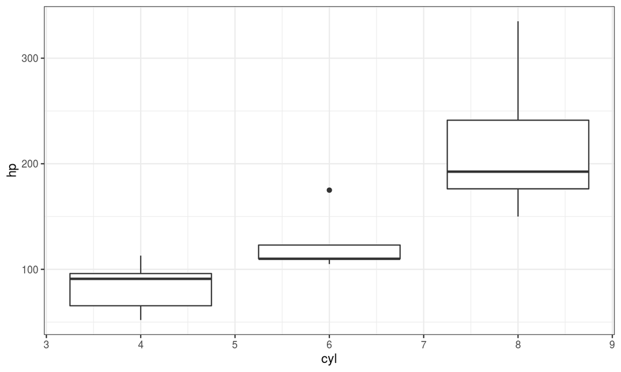

```r
ggplot(mtcars,aes(cyl,hp,group=cyl))+geom_boxplot()
```

## bag plot (2D boxplot)

(Rousseeuw et al. 1999) In `ggplot` (*note* hidden code):

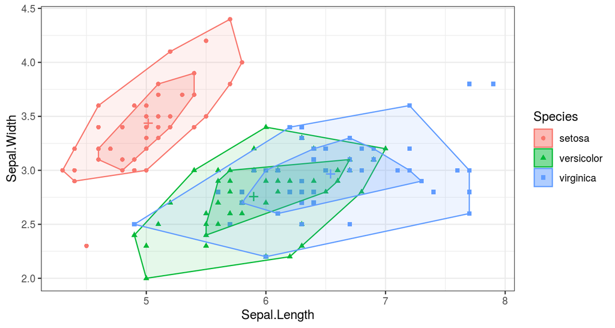

```r
ggplot(iris, aes(Sepal.Length,Sepal.Width,colour=Species,shape=Species,fill=Species))+
  geom_point()+ geom_bag()
```

The `rainbow` package implements **functional** boxplots, for high-dimensional (functional) data analysis: it uses various forms of projection or dimension reduction, followed by a bagplot of the first two projected dimensions

```r
rainbow::fboxplot(data = ElNino_ERSST_region_1and2,
                  plot.type = "bivariate",
                  type = "bag", projmethod="PCAproj")
```

## is Tukey still relevant?

- yes (principles)
- data size/complexity and computing power are both increasing

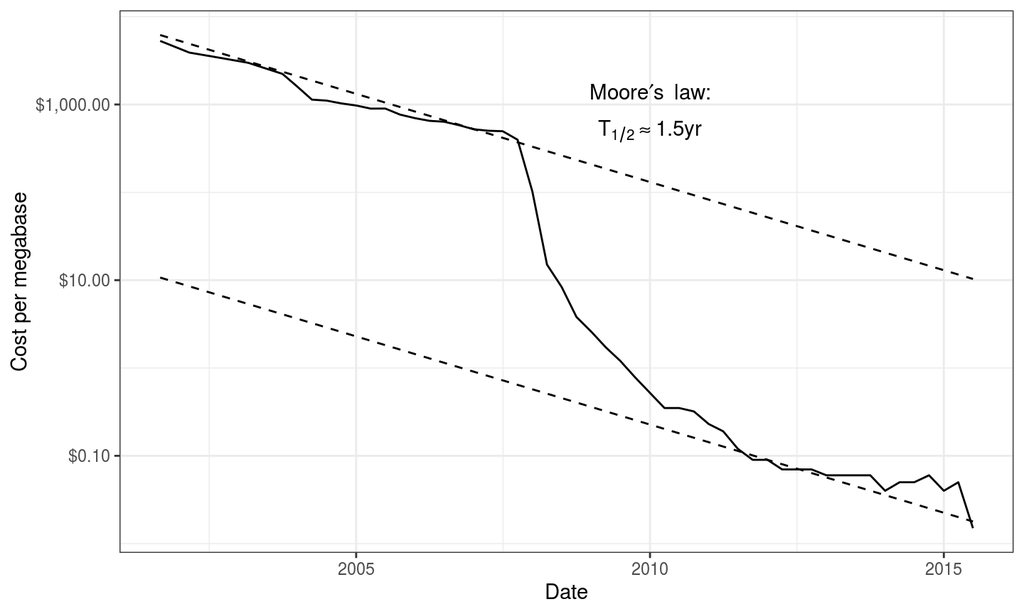

## Cleveland: quantifying viz efficacy

[figure not shown]

## principles

- accuracy of quantitative representation
- visual estimation of *differences*

## perceptual experiments

- show participants the same data in different formats
- ask them questions about relative magnitudes

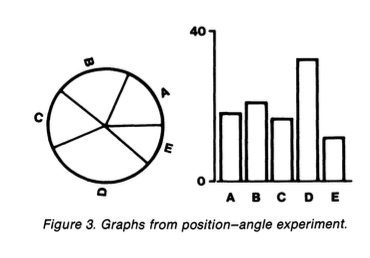

## perceptual experiments: results

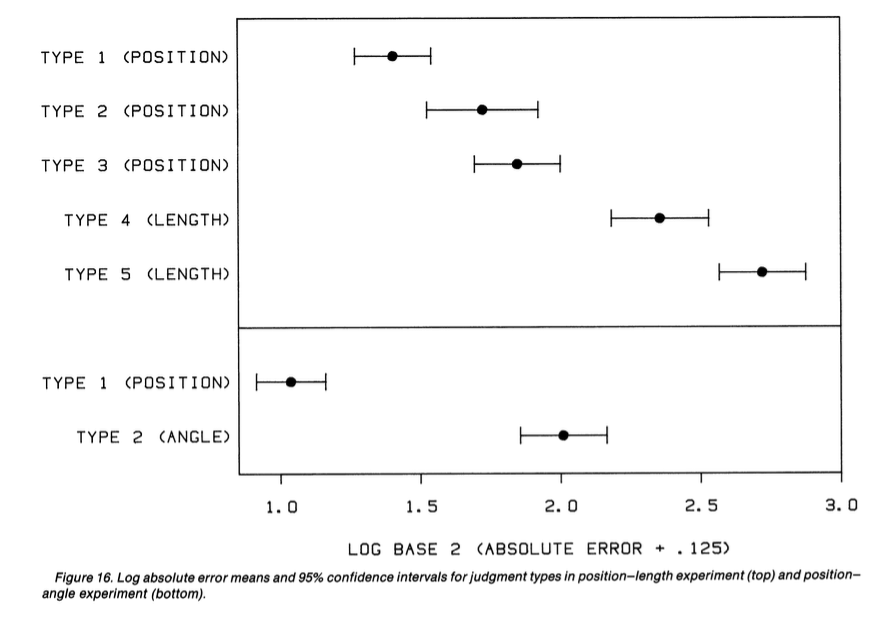

## is Cleveland still relevant?

- yes!
- Elliott (2016), "39 studies about human perception in 30 minutes"
  - healthy tradition of scientific experiments on graphical perception
    - accuracy
    - memory
    - preference

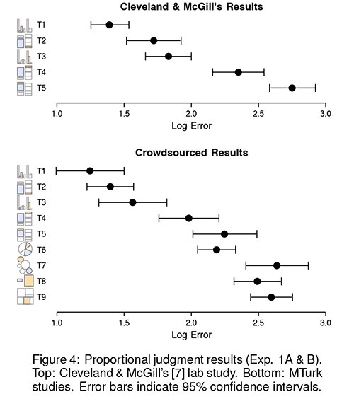

Heer et al. (2010)

## Edward Tufte

[figure not shown]

## Tufte principles

- functional, minimal graphics
- maximize data-ink / minimize non-data-ink
- don't lie (**lie factor**)
- small multiples
- "If a picture isn't worth 1000 words, the hell with it" - Ad Reinhardt
- information at the point of need (legends etc.)
- Powerpoint sucks

"Understand that Tufte’s ideas are a good starting point, not a religion" [Robert Kosara](https://eagereyes.org/criticism/edward-tufte-one-day-course)

## data ink

- maximize data ink (within reason)

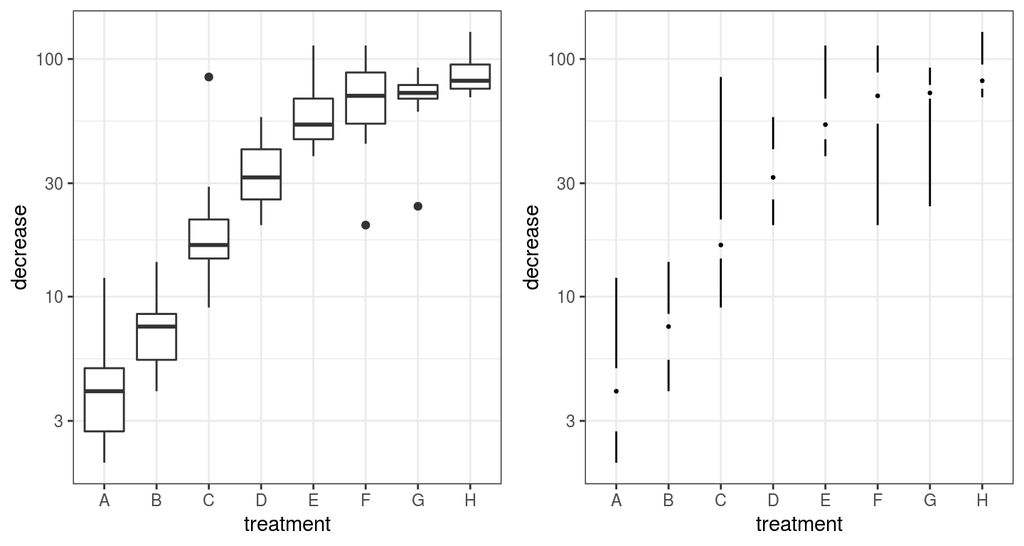

```r
g0 <- ggplot(OrchardSprays,aes(treatment,decrease))+scale_y_log10()
print(plot_grid(g0 + geom_boxplot(),  g0 + geom_tufteboxplot()))
```

`ggthemes::geom_tufteboxplot()`

## information at the point of need

- less eye movement is better
- direct labels > legends > info in caption > info in text

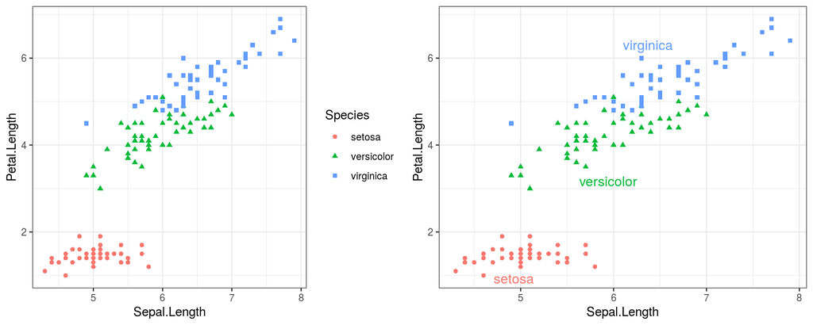

```r
g1 <- ggplot(iris,aes(Sepal.Length,Petal.Length,colour=Species,
                shape=Species))+geom_point()
print(plot_grid(g1,direct.label(g1)))
```

## direct labeling

- manually **if necessary**
- `directlabels` package
  - works with `lattice` and `ggplot` graphics
  - variety of labeling choices, e.g. `last.bumpup`: "Label last points, bumping labels up if they collide"
  - [documentation](http://directlabels.r-forge.r-project.org/docs/index.html)
- related: `ggrepel` (auto-repelling text labels)

## other

## Rules of thumb

- (Continuous) response on the \(y\)-axis
  - assumes we have a single, quantitative/ordered (continuous or discrete) response variable; multivariate responses more challenging
- put most salient predictor on the \(x\)-axis
  - highest value in Cleveland hierarchy
  - if most important predictor is categorical, use most important *continous* predictor on \(x\)-axis
  - if most important predictor has few categories, use next most important predictor with many categories

## Rules of thumb (continued)

- Put most salient comparisons within the same subplot (distinguished by color/shape), and nearby within the subplot when grouping bars/points
- Facet rows > facet columns

## Rules of thumb (3)

- Use transparency to include important but potentially distracting detail
- Do category levels need to be *identified* or just *distinguished*? (Direct labeling, e.g. via `directlabels` package)
- Order categorical variables meaningfully ("Alabama/Alberta" problem)
- Think about whether to display *population variation* (standard deviations, boxplots) or *estimation uncertainty* (standard errors, mean \(\pm\) 2 SE, boxplot notches)
- Try to match graphics to statistical analysis, but not at all costs
- Choose colors carefully (`RColorBrewer`/[ColorBrewer](http://colorbrewer2.org/), [IWantHue](http://tools.medialab.sciences-po.fr/iwanthue/): respect dichromats and B&W printouts (see `dichromat` & colorblindr & cividis packages (Sciani 2018)

## Data presentation scales with data size

- **small** show all points, possibly dodged/jittered, with some summary statistics: dotplot, beeswarm. Simple trends (linear/GLM/loess)
- **medium** boxplots, loess, histograms, GAM (or linear regression)
- **large** modern nonparametrics: violin plots, hexbin plots, kernel densities: computational burden, and display overlapping problems, relevant
- combinations or overlays where appropriate (beanplot; rugs+scatterplot)

## examples

Some examples (from a [screed on "dynamite plots"](http://emdbolker.wikidot.com/blog:dynamite)):

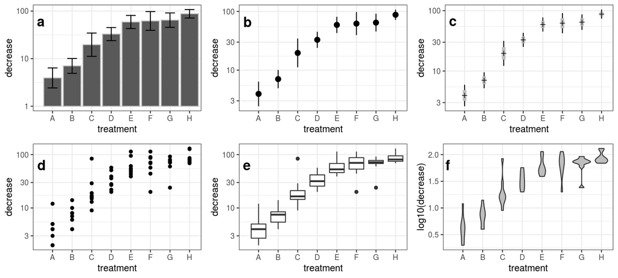

## Notes

a. the dreaded "dynamite plot". Problems:

- bar plot on logarithmic axis is inappropriate (anchors graph to arbitrary zero point)
- assumes distribution is symmetric (although this applies to b,c as well)
- some forms of this plot show only top whisker (makes comparison even harder)

b. inferential (point \(\pm\) 2 SE) plot

- same assumptions as dynamite plot
- less strongly anchored to zero

## Notes (continued)

c. points \(\pm\) 1 and 2 SE

- de-emphasizes approximate 95% CI
- equivalent for Bayesian posterior intervals would typically show both 50% and 95% credible intervals (based on quantiles or highest posterior density)

d. points alone

- true to the data
- description only; provides no inferential help
- can confound sample size and range (larger samples have more extreme values so look more variable)

## Notes (continued)

e. boxplots

- well-established
- "outliers" can be misleading (Dawson 2011)
- can add notches to indicate approximate 95% CI on medians (McGill et al. 1978)

f. violin plots

- mirror-image density plots
- best for large data sets
- may be funky for small/medium data sets
- can be combined with jittered data, segments indicating median/quantiles, etc.

## Example

- [story](https://medium.com/tdebeus/redesign-of-a-truly-bananas-chart-1617f930808d)
- [github repo](https://github.com/thomasdebeus/colourful-facts/blob/develop/projects/Redesign-of-worst-chart-ever/)
- [direct link to data](https://github.com/thomasdebeus/colourful-facts/blob/develop/projects/Redesign-of-worst-chart-ever/FAOSTAT_data_1-7-2018.csv)

## References

Dawson, R. 2011. *Journal of Statistics Education* 19 (2): 1–12.

Elliott, K. 2016. *Medium*. https://medium.com/@kennelliott/39-studies-about-human-perception-in-30-minutes-4728f9e31a73.

Heer, J et al. 2010. In *Proceedings of the SIGCHI Conference on Human Factors in Computing Systems*, 203–212. ACM.

McGill, R et al. 1978. *The American Statistician* 32 (1): 12–16. doi:10.2307/2683468. http://www.jstor.org/stable/2683468.

Rousseeuw, PJ et al. 1999. *The American Statistician* 53 (4) (November): 382–387. doi:10.1080/00031305.1999.10474494.

Sciani, M. 2018. https://github.com/marcosci/cividis.